# Compare two synthetic files with PUF

### Deduction variables, CDF plots

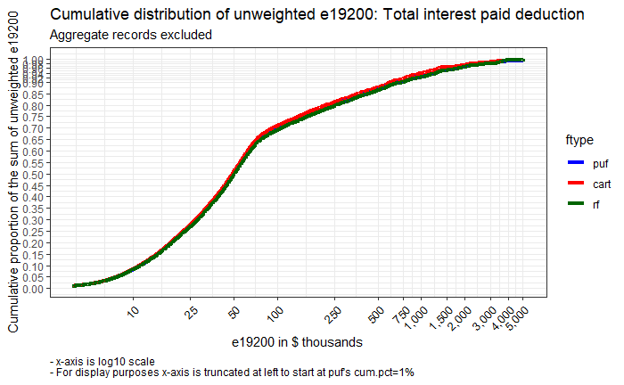

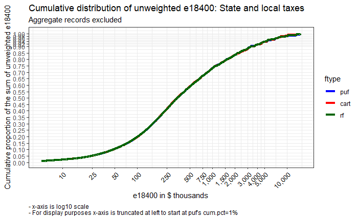

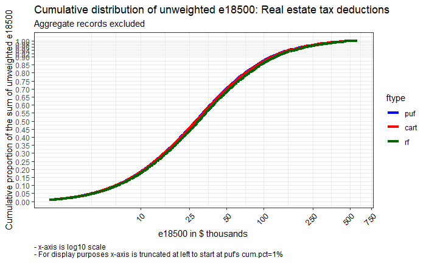

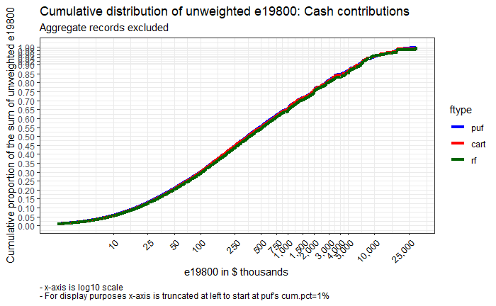

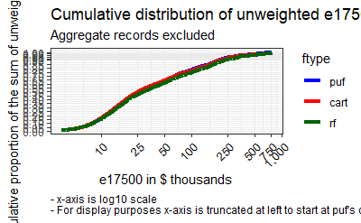

```r
l_ply(dedvars, cdfplot2)
```

# Univariate distribution measures

Relative frequency comparison:

1. Working with just the PUF file:
   - Sort each variable in ascending order
   - Divide into 1,000 bins, each with the same approx number of values (0.1% of the values)
   - Collapse the bins so that all bin cut points are unique. For example if 5% of the values were all zero, then we would have 50 bins where all the values are zero. This step collapses these into one bin with zeros.
   - Determine the cutpoints for each bin
2. Now, for each of the 3 files (PUF, cart, RF), for each variable:
   - Count the number of values for each file that are in each bin, using the PUF-based endpoints from Step 1.
   - Compute the relative frequencies.
3. For the cart and RF files, for each variable:
   - For each bin, compute the difference between the relative frequency for the file in question (cart or RF), and square it
   - Construct a summary for the variable: the sum of these squared differences
4. Construct a file summary: the median of the sum of squared differences computed in Step 3, across all continuous variables

## Relative frequencies - summary across all continuous variables

```r
# get file-total summaries, across all variables
bincomp %>%
  group_by(vname) %>%
  mutate(worst=case_when(ftype=="cart" & ssd > ssd[ftype=="rf"] ~ 1,
                         ftype=="rf" & ssd > ssd[ftype=="cart"] ~ 1,
                         TRUE ~ 0)) %>%
  group_by(ftype) %>%
  summarise(n.worst=sum(worst), ssd.mdn=median(ssd), ssd.mean=mean(ssd)) %>%
  adorn_totals() %>%
  mutate_at(vars(-ftype, -n.worst), ~ifelse(ftype=="Total", NA, .)) %>%
  mutate(n.pct=n.worst / n.worst[ftype=="Total"] * 100) %>%
  kable(caption="Summary of relative frequency comparison across all continuous variables",
        digits=c(0, 0, 2, 2, 1)) %>%
  kable_styling(full_width = FALSE)
```

Summary of relative frequency comparison across all continuous variables

| ftype | n.worst | ssd.mdn | ssd.mean | n.pct |
| --- | --- | --- | --- | --- |
| cart | 4 | 0.05 | 3.23 | 7.3 |
| rf | 51 | 0.89 | 1.56 | 92.7 |
| Total | 55 | NA | NA | 100.0 |

## Comparison of relative frequencies for large variables

```r
bincomp %>%
  spread(ftype, ssd) %>%
  mutate(abs_diff=abs(rf - cart),
         worst=ifelse(rf > cart, "rf", "cart")) %>%
  rename(cart_ssd=cart, rf_ssd=rf) %>%
  adorn_totals() %>%
  left_join(psum %>% dplyr::select(vname, vdesc, puf.billions=value)) %>%
  # arrange(-abs_diff) %>%
  arrange(-puf.billions) %>%
  kable(digits=1, format.args=list(big.mark = ',')) %>%
  kable_styling(full_width = FALSE)
```

| vname | cart_ssd | rf_ssd | abs_diff | worst | vdesc | puf.billions |
| --- | --- | --- | --- | --- | --- | --- |
| e00200 | 164.0 | 0.4 | 163.6 | cart | Salaries and wages | 6,044.8 |
| e01500 | 0.9 | 2.1 | 1.3 | rf | Total pensions and annuities received | 905.2 |
| e01700 | 0.2 | 0.9 | 0.7 | rf | Pensions and annuities included in AGI | 579.2 |
| e02400 | 0.1 | 0.4 | 0.4 | rf | Gross Social Security benefits | 495.3 |
| e02000 | 0.0 | 0.6 | 0.6 | rf | Schedule E net income or loss (+/-) | 466.9 |
| e26270 | 0.4 | 0.4 | 0.1 | cart | Combined partnership and S corporation net income/loss (+/-) | 407.3 |
| e19200 | 0.0 | 0.0 | 0.0 | rf | Total interest paid deduction | 380.2 |
| p23250 | 0.1 | 1.4 | 1.3 | rf | Long-term gains less losses | 356.9 |
| e00900 | 0.9 | 2.0 | 1.1 | rf | Business or profession (Schedule C) net profit/loss (+/-) | 279.6 |
| e18400 | 0.0 | 0.0 | 0.0 | rf | State and local taxes | 274.9 |
| e01400 | 0.6 | 3.6 | 3.0 | rf | Taxable IRA distribution | 219.1 |
| e00600 | 2.4 | 6.4 | 4.0 | rf | Dividends included in AGI | 182.3 |
| e18500 | 0.0 | 0.1 | 0.0 | rf | Real estate tax deductions | 173.1 |
| e19800 | 0.0 | 0.2 | 0.2 | rf | Cash contributions | 134.9 |
| e17500 | 0.1 | 0.4 | 0.3 | rf | Medical and dental expenses subject to reduction by AGI limit | 130.7 |
| e00650 | 1.9 | 4.8 | 2.9 | rf | Qualified Dividends | 130.6 |
| e20400 | 0.1 | 2.3 | 2.2 | rf | Miscellaneous deductions subject to AGI limitation, total | 120.7 |
| e00300 | 0.5 | 2.8 | 2.3 | rf | Interest received | 113.2 |
| e02300 | 1.1 | 1.8 | 0.7 | rf | Unemployment compensation in AGI | 92.6 |
| e00400 | 0.1 | 6.3 | 6.2 | rf | Tax-exempt interest income | 70.3 |
| e20100 | 0.0 | 4.7 | 4.6 | rf | Other than cash contributions | 34.6 |
| e87521 | 0.0 | 0.9 | 0.9 | rf | American Opportunity Credit | 29.2 |
| e00700 | 0.1 | 5.4 | 5.3 | rf | State income tax refunds | 26.9 |
| e03270 | 0.2 | 1.9 | 1.7 | rf | Self-employed health insurance deduction | 24.7 |
| e03300 | 0.1 | 1.2 | 1.2 | rf | Payments to KEOGH accounts | 19.0 |
| e32800 | 0.0 | 0.0 | 0.0 | rf | Qualifying individuals' Expenses | 18.1 |
| e87530 | 0.0 | 0.2 | 0.1 | rf | Lifetime Learning Total Qualified Expenses | 16.2 |
| e07300 | 0.1 | 4.4 | 4.3 | rf | Foreign tax | 14.0 |
| e62900 | 0.0 | 1.4 | 1.4 | rf | Alternative tax foreign tax credit | 12.6 |
| e24515 | 0.0 | 0.6 | 0.6 | rf | Unrecaptured Section 1250 gain | 11.3 |
| e03150 | 0.2 | 1.1 | 0.9 | rf | Total deductible individual retirement account (IRA) payments | 11.1 |
| e03210 | 2.5 | 1.6 | 0.9 | cart | Student Loan Interest Deduction | 9.7 |
| e03240 | 0.1 | 1.9 | 1.8 | rf | Domestic Production Activities deduction | 8.1 |
| e00800 | 0.0 | 0.0 | 0.0 | rf | Alimony received | 7.6 |
| e03500 | 0.0 | 0.0 | 0.0 | rf | Alimony paid | 7.2 |
| e09900 | 0.1 | 0.5 | 0.4 | rf | Penalty tax on IRA | 5.8 |
| e27200 | 0.0 | 0.2 | 0.2 | rf | Farm rent net income or loss (+/-) | 4.7 |
| e03230 | 0.3 | 0.2 | 0.1 | cart | Tuition and Fees Deduction | 4.2 |
| e24518 | 0.0 | 0.2 | 0.2 | rf | 28% Rate Gain or Loss | 3.9 |
| e03290 | 0.1 | 1.7 | 1.6 | rf | Health Savings Account deduction | 3.1 |
| e07400 | 0.0 | 1.7 | 1.7 | rf | General business credit | 2.4 |
| e58990 | 0.0 | 0.5 | 0.5 | rf | Investment income (Form 4952 part 2 line 4g) | 2.2 |
| e01100 | 0.3 | 0.5 | 0.2 | rf | Capital gain distributions reported on Form 1040 | 1.7 |
| e11200 | 0.0 | 1.0 | 1.0 | rf | Excess FICA/RRTA | 1.6 |
| e07260 | 0.0 | 2.0 | 1.9 | rf | Residential Energy Credit | 1.5 |
| e07240 | 0.1 | 0.1 | 0.1 | rf | Retirement Savings Credit | 1.1 |
| e03220 | 0.1 | 1.6 | 1.5 | rf | Educator Expenses | 1.0 |
| e07600 | 0.0 | 0.1 | 0.1 | rf | Credit for prior year minimum tax | 0.5 |
| e03400 | 0.0 | 0.3 | 0.3 | rf | Forfeited interest penalty | 0.5 |
| p08000 | 0.0 | 0.0 | 0.0 | rf | Other Credits | 0.1 |
| e09700 | 0.0 | 0.0 | 0.0 | rf | Recapture taxes | 0.0 |
| e09800 | 0.0 | 0.0 | 0.0 | rf | Social security tax on tip income | 0.0 |
| e02100 | 0.1 | 1.9 | 1.8 | rf | Schedule F net profit/loss (+/-) | -9.3 |
| p22250 | 0.0 | 6.8 | 6.8 | rf | Short-term gains less losses | -15.6 |
| e01200 | 0.0 | 4.4 | 4.3 | rf | Other gains (or loss) (+/-) | -17.5 |
| Total | 177.9 | 86.0 | 237.6 | - | NA | NA |

```r
NA
```

## Examine relative frequencies for wages - why does CART do so poorly?

```r
# why do wages do so poorly??
f <- function(x, y) (x - y)^2
wages <- binned %>%
  filter(vname=="e00200") %>%
  dplyr::select(ftype, vname, binnum, valgroup, pct) %>%
  spread(ftype, pct) %>%
  dplyr::select(vname, binnum, valgroup, puf, cart, rf) %>%
  mutate_at(vars(cart, rf), list(ssd=~f(., puf))) %>%
  ungroup %>%
  filter(row_number() %in% c(1:5, (nrow(.) - 4):nrow(.)))

wages %>%
  kable(digits=2) %>%
  kable_styling(full_width = FALSE)
```

| vname | binnum | valgroup | puf | cart | rf | cart_ssd | rf_ssd |
| --- | --- | --- | --- | --- | --- | --- | --- |
| e00200 | 1 | (-Inf,0] | 20.91 | 10.78 | 20.30 | 102.79 | 0.38 |
| e00200 | 2 | (0,2] | 0.01 | 1.02 | 0.01 | 1.02 | 0.00 |
| e00200 | 3 | (2,70] | 0.13 | 7.83 | 0.21 | 59.28 | 0.01 |
| e00200 | 4 | (70,90] | 0.07 | 0.64 | 0.07 | 0.33 | 0.00 |
| e00200 | 5 | (90,160] | 0.10 | 0.87 | 0.12 | 0.59 | 0.00 |
| e00200 | 786 | (4.7e+06,5.281e+06] | 0.10 | 0.10 | 0.10 | 0.00 | 0.00 |
| e00200 | 787 | (5.281e+06,6.28e+06] | 0.10 | 0.11 | 0.10 | 0.00 | 0.00 |
| e00200 | 788 | (6.28e+06,7.806e+06] | 0.10 | 0.10 | 0.10 | 0.00 | 0.00 |
| e00200 | 789 | (7.806e+06,1.151e+07] | 0.10 | 0.10 | 0.10 | 0.00 | 0.00 |
| e00200 | 790 | (1.151e+07, Inf] | 0.10 | 0.10 | 0.10 | 0.00 | 0.00 |

```r
NA
```

# Correlations

## Summary of correlations: Counts of worst differences, and median of absolute difference from PUF correlation

```r
tots <- cor.comp %>%
  summarise(n=n()) %>%
  mutate(worst="Total")

cor.comp %>%
  group_by(worst) %>%
  summarise(n=n(), absdiff.mdn=median(abs(diff.worst))) %>%
  bind_rows(tots) %>%
  mutate(n.pct=n / n[worst=="Total"] * 100) %>%
  kable(digits=c(0, 0, 4, 1), format.args=list(big.mark=",")) %>%
  kable_styling(full_width = FALSE)
```

| worst | n | absdiff.mdn | n.pct |
| --- | --- | --- | --- |
| cart | 327 | 0.0065 | 22 |
| rf | 1,158 | 0.0157 | 78 |
| Total | 1,485 | NA | 100 |

```r
NA
```

## Differences from PUF correlations, selected variable pairs

Most-negative PUF correlations

| vname1 | vname2 | vdesc1 | vdesc2 | cor.puf | cor.cart | cor.rf | diff.cart | diff.rf | diff.worst | worst |
| --- | --- | --- | --- | --- | --- | --- | --- | --- | --- | --- |
| e02400 | e87521 | Gross Social Security benefits | American Opportunity Credit | -0.087 | -0.083 | -0.082 | 0.004 | 0.005 | 0.005 | rf |
| e02400 | e32800 | Gross Social Security benefits | Qualifying individuals' Expens | -0.075 | -0.072 | -0.072 | 0.002 | 0.003 | 0.003 | rf |
| e26270 | p22250 | Combined partnership and S cor | Short-term gains less losses | -0.066 | -0.032 | -0.037 | 0.035 | 0.029 | 0.035 | cart |
| e18500 | e87521 | Real estate tax deductions | American Opportunity Credit | -0.066 | -0.065 | -0.064 | 0.000 | 0.002 | 0.002 | rf |
| e02000 | p22250 | Schedule E net income or loss | Short-term gains less losses | -0.062 | -0.036 | -0.032 | 0.026 | 0.031 | 0.031 | rf |
| e02400 | e03210 | Gross Social Security benefits | Student Loan Interest Deductio | -0.062 | -0.070 | -0.055 | -0.008 | 0.007 | 0.008 | cart |
| e03210 | e18500 | Student Loan Interest Deductio | Real estate tax deductions | -0.053 | -0.062 | -0.050 | -0.008 | 0.003 | 0.008 | cart |
| e24515 | e26270 | Unrecaptured Section 1250 gain | Combined partnership and S cor | -0.053 | -0.046 | -0.055 | 0.007 | -0.002 | 0.007 | cart |
| e02000 | e24515 | Schedule E net income or loss | Unrecaptured Section 1250 gain | -0.052 | -0.041 | -0.049 | 0.011 | 0.003 | 0.011 | cart |
| e02300 | e18500 | Unemployment compensation in A | Real estate tax deductions | -0.045 | -0.044 | -0.036 | 0.002 | 0.009 | 0.009 | rf |
| e02400 | e03290 | Gross Social Security benefits | Health Savings Account deducti | -0.045 | -0.033 | -0.025 | 0.012 | 0.020 | 0.020 | rf |
| e00200 | e02400 | Salaries and wages | Gross Social Security benefits | -0.044 | -0.038 | -0.040 | 0.005 | 0.004 | 0.005 | cart |
| e00200 | e87521 | Salaries and wages | American Opportunity Credit | -0.043 | -0.044 | -0.045 | -0.001 | -0.001 | 0.001 | rf |
| e07240 | e18500 | Retirement Savings Credit | Real estate tax deductions | -0.043 | -0.046 | -0.039 | -0.002 | 0.004 | 0.004 | rf |
| e02300 | e03270 | Unemployment compensation in A | Self-employed health insurance | -0.042 | -0.035 | -0.023 | 0.008 | 0.019 | 0.019 | rf |

### 15 worst correlation differences

```r
vsize <- 30
cor.comp %>%
  arrange(desc(diff.worst)) %>%
  mutate(vdesc1=str_sub(vdesc1, 1, vsize), vdesc2=str_sub(vdesc2, 1, vsize)) %>%
  arrange(desc(diff.worst)) %>%
  mutate(vdesc1=str_sub(vdesc1, 1, vsize), vdesc2=str_sub(vdesc2, 1, vsize)) %>%
  head(15) %>%
  rename(cor.puf=puf, cor.cart=cart, cor.rf=rf) %>%
  kable(digits=3) %>%
  kable_styling(full_width = FALSE)
```

| vname1 | vname2 | vdesc1 | vdesc2 | cor.puf | cor.cart | cor.rf | diff.cart | diff.rf | diff.worst | worst |
| --- | --- | --- | --- | --- | --- | --- | --- | --- | --- | --- |
| e07400 | e19800 | General business credit | Cash contributions | 0.067 | 0.083 | 0.238 | 0.015 | 0.170 | 0.170 | rf |
| e03240 | e07400 | Domestic Production Activities | General business credit | 0.209 | 0.220 | 0.348 | 0.011 | 0.139 | 0.139 | rf |
| e07400 | e62900 | General business credit | Alternative tax foreign tax cr | 0.027 | 0.081 | 0.149 | 0.054 | 0.122 | 0.122 | rf |
| e07300 | e07400 | Foreign tax | General business credit | 0.028 | 0.079 | 0.145 | 0.050 | 0.116 | 0.116 | rf |
| e00600 | e07400 | Dividends included in AGI | General business credit | 0.034 | 0.071 | 0.145 | 0.037 | 0.111 | 0.111 | rf |
| e02100 | e58990 | Schedule F net profit/loss (+/ | Investment income (Form 4952 p | -0.042 | 0.001 | -0.151 | 0.043 | -0.109 | 0.109 | rf |
| e19200 | e20100 | Total interest paid deduction | Other than cash contributions | 0.068 | 0.139 | 0.177 | 0.071 | 0.109 | 0.109 | rf |
| e00600 | e00700 | Dividends included in AGI | State income tax refunds | 0.128 | 0.183 | 0.236 | 0.055 | 0.108 | 0.108 | rf |
| e07400 | e07600 | General business credit | Credit for prior year minimum | 0.008 | 0.035 | 0.112 | 0.027 | 0.104 | 0.104 | rf |
| e00650 | p23250 | Qualified Dividends | Long-term gains less losses | 0.158 | 0.259 | 0.230 | 0.101 | 0.072 | 0.101 | cart |
| e20100 | e20400 | Other than cash contributions | Miscellaneous deductions subje | 0.199 | 0.203 | 0.300 | 0.004 | 0.101 | 0.101 | rf |
| e00400 | e07400 | Tax-exempt interest income | General business credit | 0.039 | 0.049 | 0.135 | 0.010 | 0.096 | 0.096 | rf |
| e00600 | e58990 | Dividends included in AGI | Investment income (Form 4952 p | 0.049 | 0.072 | 0.143 | 0.022 | 0.094 | 0.094 | rf |
| e00600 | e03240 | Dividends included in AGI | Domestic Production Activities | 0.071 | 0.098 | 0.163 | 0.027 | 0.092 | 0.092 | rf |
| e18400 | e20100 | State and local taxes | Other than cash contributions | 0.152 | 0.232 | 0.243 | 0.079 | 0.091 | 0.091 | rf |

```r
NA
```

### 15 worst differences in correlation with wages

```r
vsize <- 30
cor.comp %>%
  filter(vname1=="e00200" | vname2=="e00200") %>%
  mutate(vname=ifelse(vname1=="e00200", vname2, vname1),
         vdesc=ifelse(vname1=="e00200", vdesc2, vdesc1)) %>%
  dplyr::select(-c(vname1, vname2, vdesc1, vdesc2)) %>%
  mutate(vdesc=str_sub(vdesc, 1, vsize)) %>%
  arrange(desc(diff.worst)) %>%
  head(15) %>%
  rename(cor.puf=puf, cor.cart=cart, cor.rf=rf) %>%
  dplyr::select(vname, vdesc, everything()) %>%
  kable(caption="Worst correlations with wages, compared to PUF", digits=3) %>%
  kable_styling(full_width = FALSE)
```

Worst correlations with wages, compared to PUF

| vname | vdesc | cor.puf | cor.cart | cor.rf | diff.cart | diff.rf | diff.worst | worst |
| --- | --- | --- | --- | --- | --- | --- | --- | --- |
| e00600 | Dividends included in AGI | 0.088 | 0.124 | 0.173 | 0.036 | 0.085 | 0.085 | rf |
| e00650 | Qualified Dividends | 0.080 | 0.105 | 0.154 | 0.025 | 0.074 | 0.074 | rf |
| e00300 | Interest received | 0.063 | 0.129 | 0.135 | 0.066 | 0.072 | 0.072 | rf |
| p23250 | Long-term gains less losses | 0.072 | 0.143 | 0.105 | 0.071 | 0.033 | 0.071 | cart |
| e00400 | Tax-exempt interest income | 0.089 | 0.105 | 0.147 | 0.016 | 0.058 | 0.058 | rf |
| e20100 | Other than cash contributions | 0.114 | 0.062 | 0.104 | -0.053 | -0.010 | 0.053 | cart |
| e20400 | Miscellaneous deductions subje | 0.119 | 0.144 | 0.165 | 0.025 | 0.046 | 0.046 | rf |
| e07600 | Credit for prior year minimum | 0.026 | 0.050 | 0.068 | 0.024 | 0.042 | 0.042 | rf |
| p22250 | Short-term gains less losses | 0.014 | 0.019 | 0.056 | 0.005 | 0.042 | 0.042 | rf |
| e11200 | Excess FICA/RRTA | 0.155 | 0.167 | 0.195 | 0.012 | 0.040 | 0.040 | rf |
| e07400 | General business credit | 0.034 | 0.044 | 0.074 | 0.010 | 0.040 | 0.040 | rf |
| e00700 | State income tax refunds | 0.154 | 0.173 | 0.193 | 0.020 | 0.039 | 0.039 | rf |
| e19800 | Cash contributions | 0.109 | 0.112 | 0.147 | 0.003 | 0.039 | 0.039 | rf |
| e03290 | Health Savings Account deducti | 0.005 | 0.022 | 0.040 | 0.017 | 0.035 | 0.035 | rf |
| e58990 | Investment income (Form 4952 p | 0.011 | 0.022 | 0.046 | 0.011 | 0.034 | 0.034 | rf |

```r
NA
```

# Bivariate plots

## Selected variables vs. MARS

```r
bvplot_MARS <- function(vname){
  vdesc <- puf.vnames$vdesc[puf.vnames$vname==vname]
  p <- stack %>%
    dplyr::select(ftype, MARS, value=vname) %>%
    filter((vname=="e00200") | (value > 0)) %>%
    mutate(ftype=factor(ftype, levels=c("puf", "cart", "rf")),
           marsgroup=case_when(MARS==1 ~ "single",
                               MARS==2 ~ "married",
                               MARS %in% 3:4 ~ "other"),
           marsgroup=factor(marsgroup, levels=c("single", "married", "other")),
           lvalue=log(value + 1)) %>%
  ggplot(aes(ftype, lvalue, colour=ftype)) +
  scale_colour_manual(values=c("blue", "red", "darkgreen")) +
  geom_boxplot() +
  theme_bw() +
  ggtitle("Log 10 of value by marital status and file type",
          subtitle = vdesc) +
  facet_wrap(~marsgroup, nrow=1, scales="free_y")
  print(p)
  return(p)
}
# bvplot_MARS(incvars[1])
```

### Income variables, bivariate plots by MARS

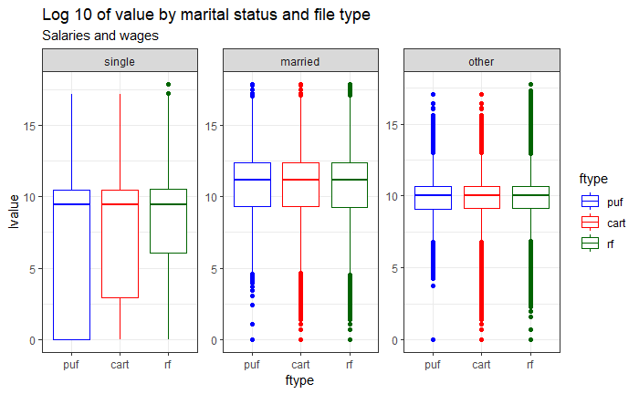

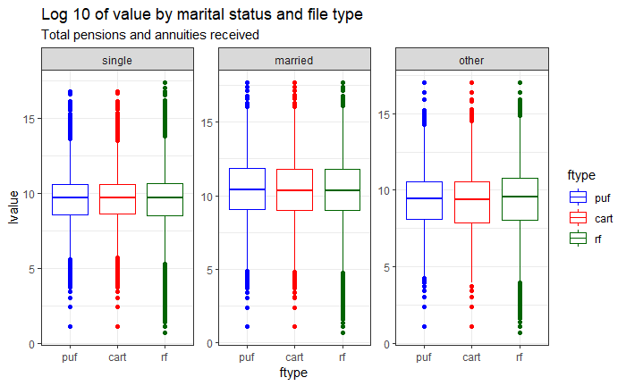

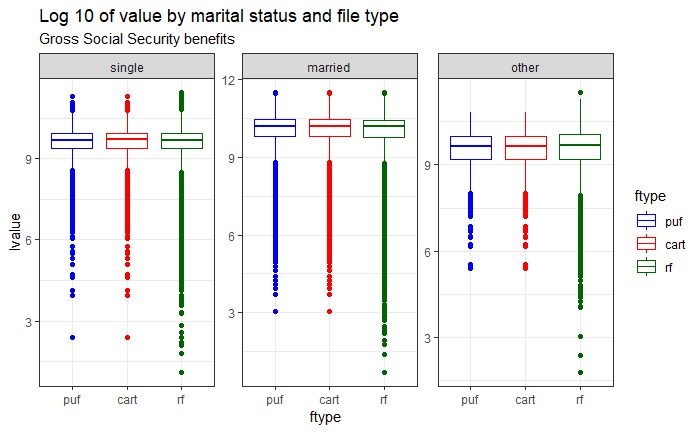

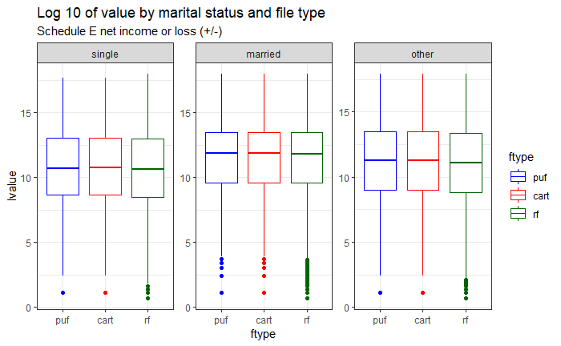

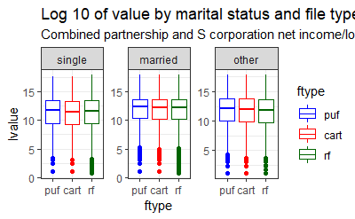

```r
l_ply(incvars, bvplot_MARS)
```

### Deduction variables, bivariate plots by MARS

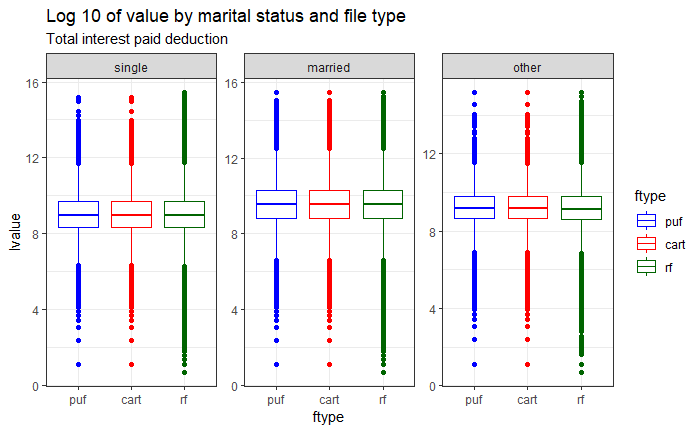

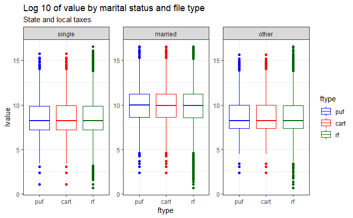

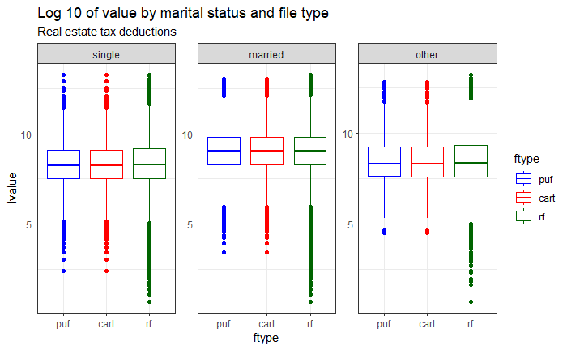

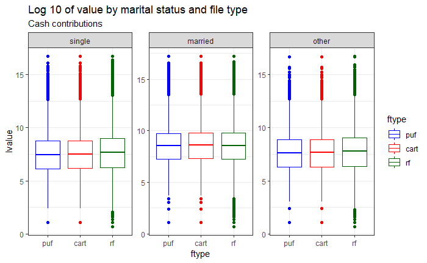

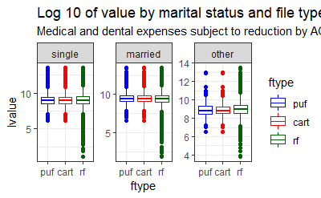

```r
l_ply(dedvars, bvplot_MARS)
```